# KI-RIKEN 2024 Assignment 1

## Task4 - Using R example datasets

**the CO2 data set** : Carbon Dioxide Uptake in Grass Plants data

- Plant: an ordered factor with levels giving a unique identifier for each plant
- Type: a factor with levels giving the origin of the plant
- Treatment:a factor with levels nonchilled chilled
- conc: a numeric vector of ambient carbon dioxide concentrations(mL/L)
- uptake:a numeric vector of carbon dioxide uptake rates$(\mu mol/m^{2} sec)$

```r
data(CO2)

# Quebec
## average
Q_ave <-mean(CO2$uptake[CO2$Type=='Quebec'])
## median
Q_med <- median(CO2$uptake[CO2$Type=='Quebec'])

# Mississippi
## average
M_ave <- mean(CO2$uptake[CO2$Type=='Mississippi'])
## median
M_med <- median(CO2$uptake[CO2$Type=='Mississippi'])

# output
## Quebec
cat("CO2 uptake of the plants from Quebec - average:", Q_ave, ", median:", Q_med, "\n")
```

```
## CO2 uptake of the plants from Quebec - average: 33.54286 , median: 37.15
```

```r
## Mississippi
cat("CO2 uptake of the plants from Mississippi - average:", M_ave, ", median:", M_med, "\n")
```

```
## CO2 uptake of the plants from Mississippi - average: 20.88333 , median: 19.3
```

**airway data set** : Read counts in genes for an RNA-Seq experiment on four human airway smooth muscle cell lines

```r
data('airway')
#count data
count_data<-assay(airway)

#expressed_in_each_sample
expressed_in_each_sample <- colSums(count_data >0)
#not_expressed_in_any_sample
expressed_in_any_sample <- rowSums(count_data>0)>0
not_expressed_in_any_sample <- sum(!expressed_in_any_sample)

## expressed_in_each_sample
cat("The number of genes expressed in each sample:", "\n")
```

```
## The number of genes expressed in each sample:
```

```r
cat(paste(names(expressed_in_each_sample), expressed_in_each_sample, sep=': ', collapse='\n'), "\n")
```

```
## SRR1039508: 24633
## SRR1039509: 24527
## SRR1039512: 25699
## SRR1039513: 23124
## SRR1039516: 25508
## SRR1039517: 25998
## SRR1039520: 24662
## SRR1039521: 23991
```

```r
## not_expressed_in_any_sample
cat("The number of genes not expressed in any sample:", not_expressed_in_any_sample, "\n")
```

```
## The number of genes not expressed in any sample: 30208
```

## Task5 - R Functions

1. A function that calculates the ratio of the mean and the median of a given vector

```r
calculates_ratio<-function(vec){
  ## Calculate the mean of the vector
  mean_val <- mean(vec, na.rm = TRUE)
  ## Calculate the median of the vector
  median_val <- median(vec, na.rm = TRUE)
  ## Calculate the ratio of the mean and the median
  ratio <- mean_val / median_val

  return(ratio)
}
#example
dat<-c(3,4,5,1,2,6,7,8,9)
calculates_ratio(dat)
```

```
## [1] 1
```

2. A function that ignores the lowest and the highest value from a given vector and calculate the mean

```r
calculate_mean<-function(vec){
  #sort the vector to find the lowest and the highest value
  sort_data<-sort(vec)
  #Remove the lowest and highest value
  trim_data<-sort_data[-c(1,length(vec))]
  ##calculate the mean
  mean_val <- mean(trim_data,na.rm = TRUE)

  return(mean_val)
}
#example
dat<-c(3,4,5,1,2,6,7,8,9)
calculate_mean(dat)
```

```
## [1] 5
```

3. **Piping**  
   Pipes (%>%) streamline code readability by allowing you to pass outputs from one function directly into the next. Use pipes for sequential operations, enhancing clarity. Avoid them when functions require multiple inputs, as it can obscure the logic or lead to confusion in complex operations.
4. **The apply-family of functions (apply, lapply, sapply etc.)**  
   The apply family (e.g., apply, lapply, sapply) efficiently applies functions to elements of data structures. They’re useful for reducing loops, simplifying code, and handling lists or matrices, which can enhance performance and clarity when processing data in a functional programming style.

## Task6 - Basic visualization with R

1. Compare the distributions of the body heights of the two species from the’magic_guys.csv’ dataset graphically 1-a

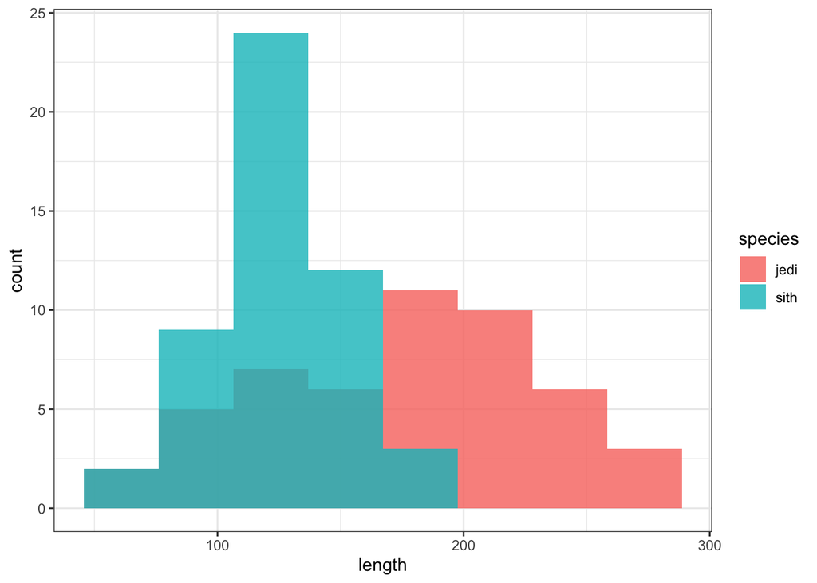

```r
data_csv<-read.csv("~/R/KI-RIKEN joint bioinformatics course 2024/data/magic_guys.csv")
#histgram length each species
plot_hist <- ggplot(data = data_csv,aes(x=length,fill = species))+
  geom_histogram(position = "identity", alpha = 0.8,bins = 8)+theme_bw()
plot(plot_hist)
```

1-b

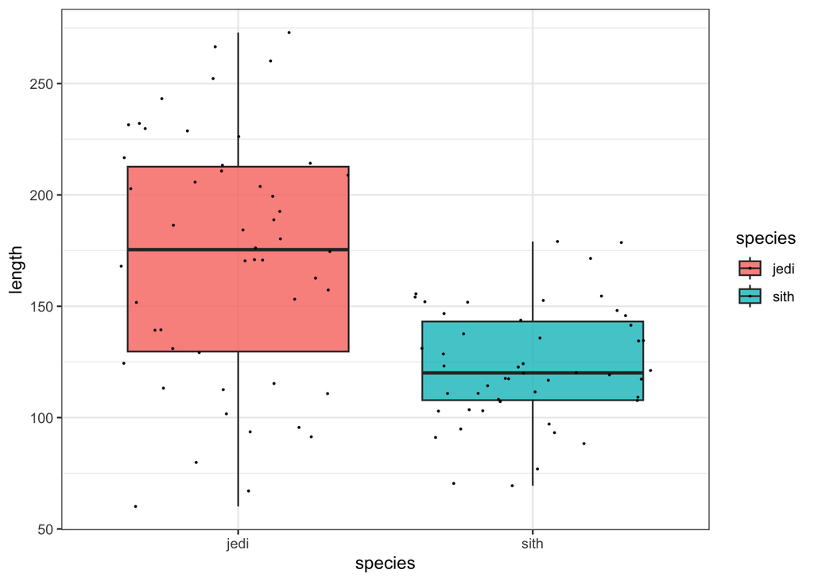

```r
#box plot length each species
plot_box <- ggplot(data = data_csv,aes(x=species,y=length,fill = species))+
  geom_boxplot(alpha = 0.8)+theme_bw()+geom_jitter(size = 0.2)
plot(plot_box)
```

1-c  
- **png**:Data can be restored to its pre-compression state, resulting in high-quality images  
- **pdf**:Documents containing high-quality images can be created efficiently.  
- **svg**:Scalable and resizable as needed. It can be designed at any resolution, allowing images to be enlarged or reduced without losing quality or becoming pixelated.  
2. Load the gene expression data matrix from the ‘microarray_data.tab’ dataset provided in the shared folder, it is a big tabular separated matrix.

```r
# 2-a
data_tab<-read.table("~/R/KI-RIKEN joint bioinformatics course 2024/data/microarray_data.tab",header =TRUE,sep = "\t",na.strings = "")
cat("microarray data matrix:rows(The number of sample)",nrow(data_tab),",columns(The number of gene)",ncol(data_tab), "\n")
```

```
## microarray data matrix:rows(The number of sample) 553 ,columns(The number of gene) 1000
```

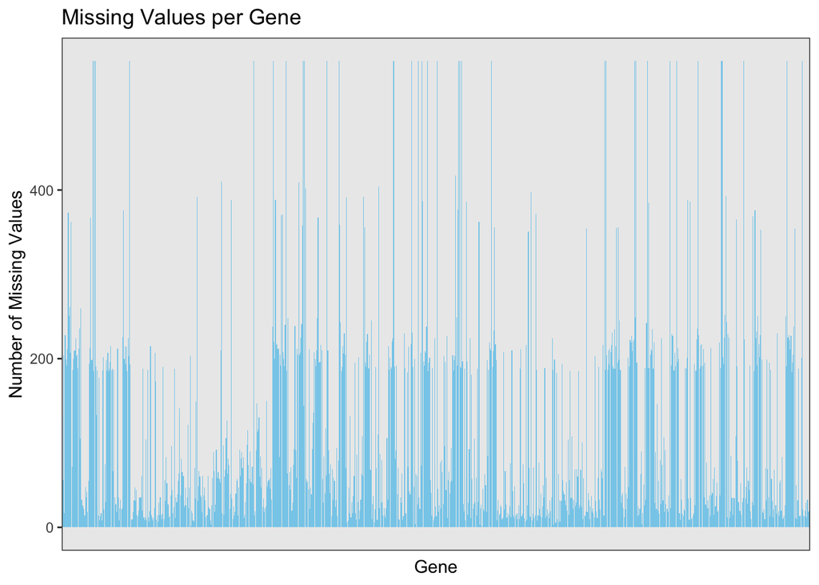

```r
# 2-b
#missing values per gene
missing_per_gene <- colSums(is.na(data_tab))
data_missing<-data.frame(Gene = names(missing_per_gene),MissingCount=as.numeric(missing_per_gene),Ratio=as.numeric(missing_per_gene)/nrow(data_tab))

#visualize
##Missing Values per Gene
plot_miss_bar<-ggplot(data = data_missing,aes(x=Gene,y=MissingCount))+
  geom_bar(stat = "identity", fill = "skyblue")+theme_bw()+
  theme(axis.text.x = element_blank(),axis.ticks.x = element_blank())+
  labs(title = "Missing Values per Gene", x = "Gene", y = "Number of Missing Values")
print(plot_miss_bar)
```

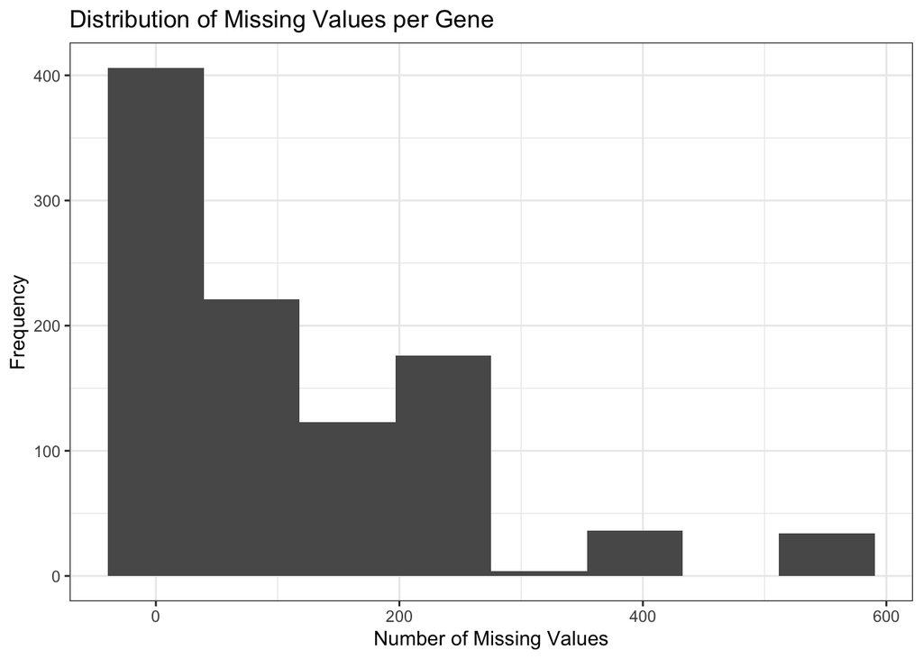

```r
##Distribution of Missing Values per Gene
plot_miss_hist<-ggplot(data = data_missing,aes(x=MissingCount))+geom_histogram(bins = 8)+
  theme_bw()+
  labs(title = "Distribution of Missing Values per Gene", x = "Number of Missing Values", y = "Frequency")
plot(plot_miss_hist)
```

```r
# 2-c
#Find the genes for which there are more than X% (X=10%, 20%, 50%) missing values.
thresholds <- c(0.10, 0.20, 0.50)
gene_thresholds<-lapply(thresholds,function(Ratio){
  missing_gene<-data_missing$Gene[data_missing$Ratio > Ratio]
  return(missing_gene)
})
names(gene_thresholds)<-paste(thresholds*100,"%",sep = "")
#print(head(gene_thresholds))

# 2-d
##calculate the mean each gene
mean_value<-sapply(data_tab,function(g){
  if (all(is.na(g))){
    return(NA)
  }else{
    return(mean(g,na.rm=TRUE))
  }
})
data_mean_each_gene<-data.frame(Gene=names(mean_value),Mean=as.numeric(mean_value))
##Replace the missing values by the average expression value
data_replace_mean<-data_tab %>%
  mutate(across(everything(),~ifelse(is.na(.),data_mean_each_gene$Mean[data_mean_each_gene$Gene == cur_column()],.)))
```

3. Visualize the data in the CO2 dataset

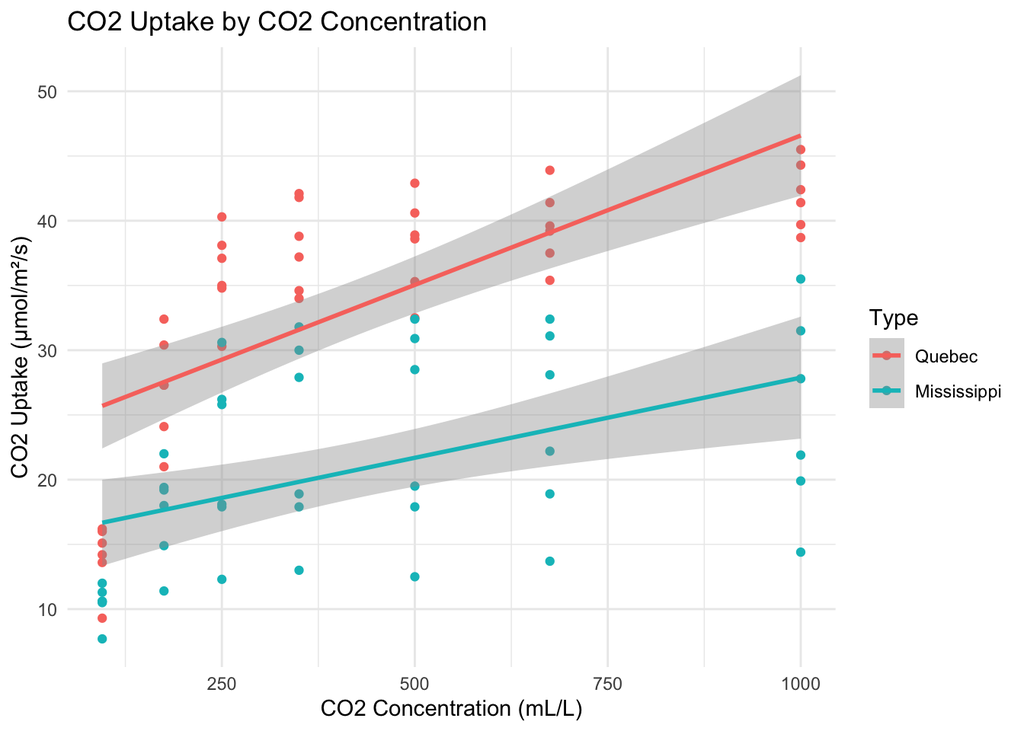

```r
plot_CO2<-ggplot(CO2, aes(x = conc, y = uptake, color = Type)) +
    geom_point() +
    geom_smooth(method = "lm") +
    labs(title = "CO2 Uptake by CO2 Concentration", x = "CO2 Concentration (mL/L)", y = "CO2 Uptake (μmol/m²/s)") +
    theme_minimal()
plot(plot_CO2)
```

## Task7

```r
# Load the chromosome data
data("chromosome")
# 1-a
## Extract summary statistics
summary_stats <- chromosome %>%
  summarize(
    mean.variations = mean(variations, na.rm = TRUE),
    median.variations = median(variations, na.rm = TRUE),
    max.variations = max(variations, na.rm = TRUE),

    mean.protein_coding_genes = mean(protein_codinggenes, na.rm = TRUE),
    median.protein_coding_genes = median(protein_codinggenes, na.rm = TRUE),
    max.protein_coding_genes = max(protein_codinggenes, na.rm = TRUE),

    mean.miRNAs = mean(mi_rna, na.rm = TRUE),
    median.miRNAs = median(mi_rna, na.rm = TRUE),
    max.miRNAs = max(mi_rna, na.rm = TRUE)
  ) %>%
  pivot_longer(everything(),names_to = c("Statistic", ".value"), names_sep = "\\.") %>%
  as.data.frame()
print(summary_stats)
```

```
##   Statistic variations protein_coding_genes    miRNAs
## 1      mean    6484572             849.9583  73.16667
## 2    median    6172346             836.0000  75.00000
## 3       max   12945965            2058.0000 134.00000
```

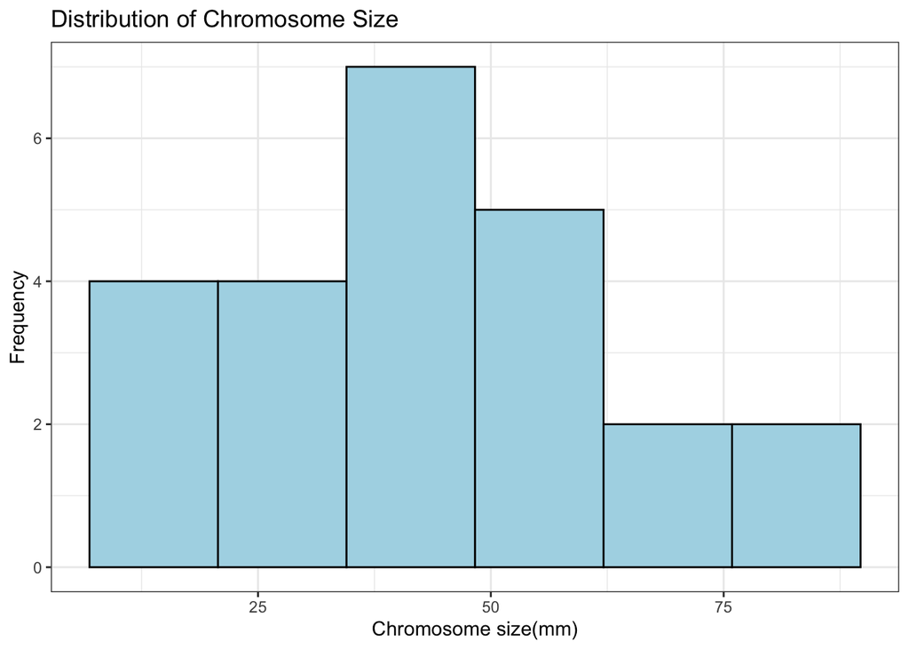

```r
# 1-b
##the chromosome size distribute
plot_chromosome_size<-ggplot(data = chromosome,aes(x=length_mm))+
  geom_histogram(bins = 6,fill = "lightblue", color = "black")+labs(title = "Distribution of Chromosome Size", x = "Chromosome size(mm)", y = "Frequency") + theme_bw()
plot(plot_chromosome_size)
```

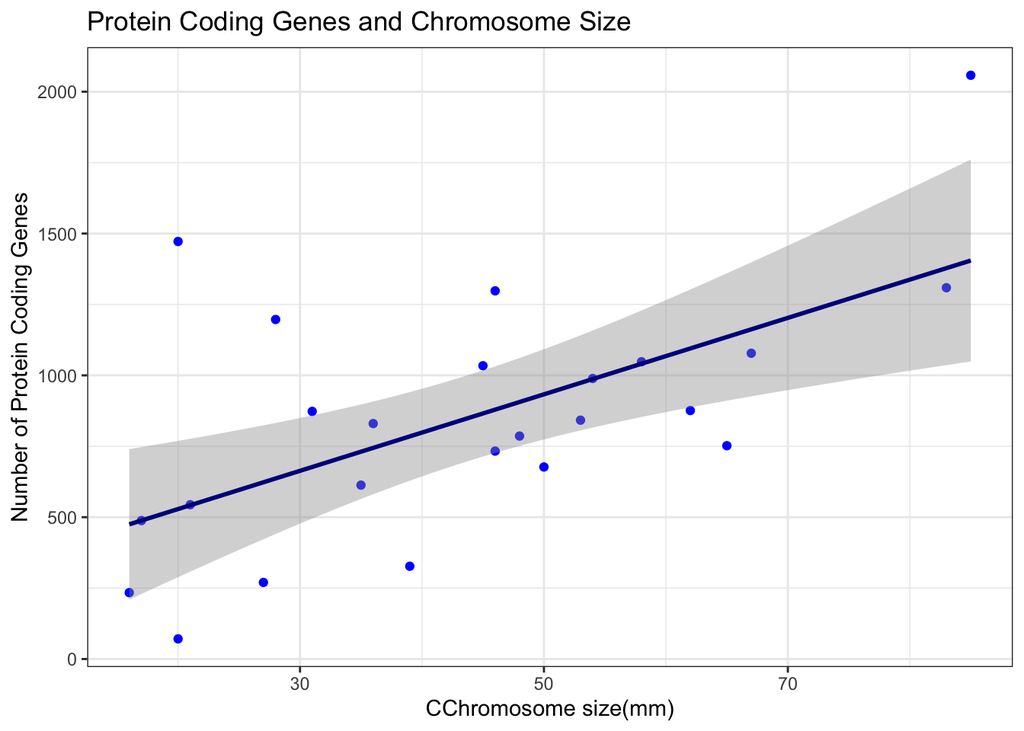

```r
# 1-c
##protein_coding_genes
plot_pro_len <- ggplot(data=chromosome, aes(x = length_mm, y = protein_codinggenes))+
  geom_point(color = "blue") +
  geom_smooth(method = "lm", color = "darkblue") +
  labs(title = "Protein Coding Genes and Chromosome Size", x = "CChromosome size(mm)", y = "Number of Protein Coding Genes") +
  theme_bw()
plot(plot_pro_len)
```

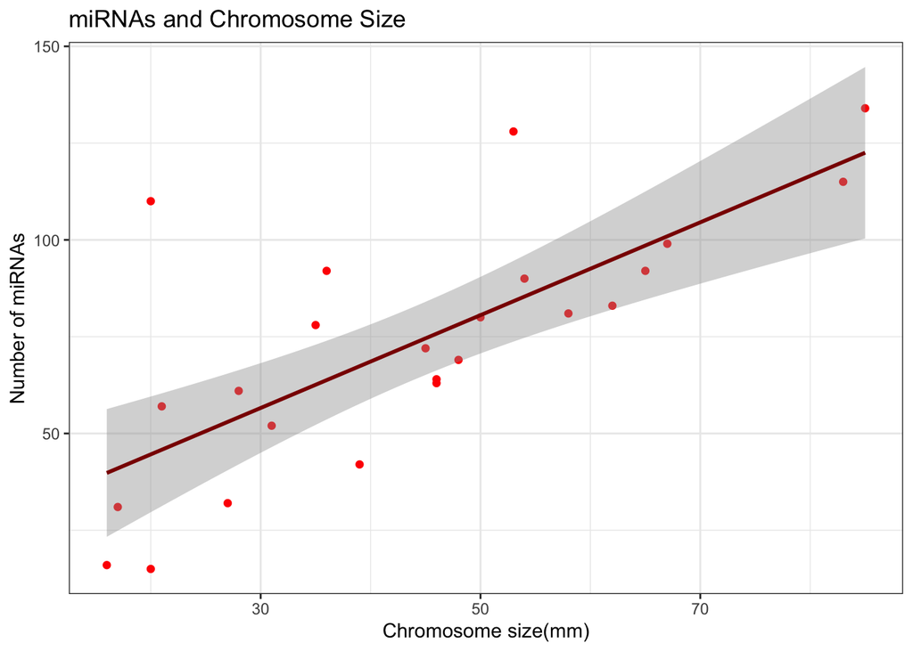

```r
##miRNA
plot_mi_len<-ggplot(data=chromosome, aes(x = length_mm, y = mi_rna)) +
  geom_point(color = "red") +
  geom_smooth(method = "lm", color = "darkred") +
  labs(title = "miRNAs and Chromosome Size", x = "Chromosome size(mm)", y = "Number of miRNAs") +
  theme_bw()
plot(plot_mi_len)
```

1-d

```r
# Load the proteins data
data("proteins")
# Extract summary statistics
protein_summary <- proteins %>%
  summarize(
    mean_length = mean(length, na.rm = TRUE),
    median_length = median(length, na.rm = TRUE),
    max_length = max(length, na.rm = TRUE),

    mean_mass = mean(mass, na.rm = TRUE),
    median_mass = median(mass, na.rm = TRUE),
    max_mass = max(mass, na.rm = TRUE)
  ) %>%
  pivot_longer(everything(),names_to = c("Statistic", ".value"), names_sep = "_") %>%
  as.data.frame()
print(protein_summary)
```

```
##   Statistic     length       mass
## 1      mean   557.1603   62061.38
## 2    median   414.0000   46140.50
## 3       max 34350.0000 3816030.00
```

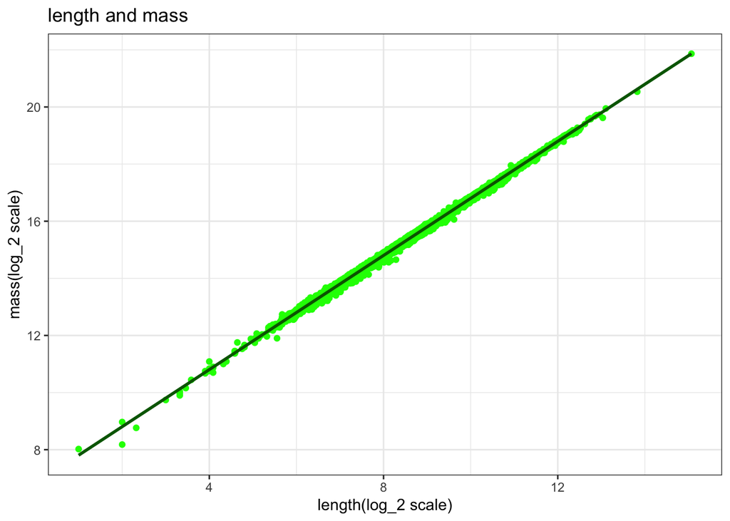

```r
plot_len_mass<-ggplot(data=proteins, aes(x = log(length,base = 2), y =log(mass,base = 2))) +
    geom_point(color = "green") +
    geom_smooth(method = "lm", color = "darkgreen") +
    labs(title = "length and mass", x = "length(log_2 scale)", y = "mass(log_2 scale)") +
    theme_bw()
plot(plot_len_mass)
```